# 03b_numpy_tutorial

# Numpy array

Thomas Hauser (thomas.hauser@colorado.edu)

Shelley Knuth (shelley.knuth@colorado.edu)

adapted from the exellent ipython notebooks by J.R. Johansson (robert@riken.jp) http://dml.riken.jp/~rob/. The other notebooks from J.R. Johansson are available at http://jrjohansson.github.com.

## Further reading

- https://docs.python.org/2/tutorial/index.html
- http://numpy.scipy.org
- http://scipy.org/Tentative_NumPy_Tutorial
- http://scipy.org/NumPy_for_Matlab_Users - A Numpy guide for MATLAB users.

## Working with a data file

### IPython can work as a better shell

```python
files = !ls *.txt
notebook_files = !ls *.ipynb
```

```python
print files
print notebook_files
```

```
['rita-2009-2009.txt']
['00_initialize.ipynb', '01_introduction.ipynb', '02_numpyTutorial.ipynb', '02_starting_notebooks.ipynb', '03_overview.ipynb', '04_example.ipynb', '05_pandas.ipynb', '06_pandas_example.ipynb', 'Git_Introduction.ipynb']
```

### Our first lists

https://docs.python.org/2/tutorial/datastructures.html

** Indexing starts at 0 in python **

```python
print type(notebook_files)
!head -c 45 {files[0]}
```

```
<class 'IPython.utils.text.SList'>
Year	Month	Day	Hour	dir	vel	tist	pres	rh	rmed
```

## Reading in a data file

- We will read in the file
- Only Month, Day, Hour and vel column

### In Matlab

To open a file, read in data, and assign variables in Matlab:

```matlab
    fid=fopen('rita-2009-2009.txt','r');
    data=textscan(fid,'%d%d%d%d%f%f%f%f%f%f','Delimiter' ',','HeaderLines',1);
    month=data{2};
    day=data{3};
    hour=data{4};
    velocity=data{6};
    fclose(fid)
```

### Open file and read data

Using the numpy module: http://www.numpy.org

Numpy User Guide: http://docs.scipy.org/doc/numpy/user/index.html#user

```python
import numpy as np

np.set_printoptions(threshold=50)
month,day,hour,velocity = np.loadtxt(files[0],
                                        unpack=True,
                                        skiprows=1, dtype="i8,i8,i8,f8",
                                        usecols=(1,2,3,5))
print velocity
```

```
[ 17.  13.  19. ...,  39.  50.  22.]
```

```python
velocity[:10]
```

```
array([ 17.,  13.,  19.,   9.,  24.,  46.,  38.,  50.,  53.,  57.])
```

## Storing the data in a Python dictionary

** Matlab using Containers.Map **

A dictionory is a data structure that contains unique key-value pair. It is a data structure that can help to organize the data

http://www.openbookproject.net/thinkcs/python/english2e/ch12.html

- Create an empty dictionary
- Extract the data and the key out of our 3 lists
- Convert the data to integers and floating point numbers
- Add some meta data with the key `description`

```python
data_set = {}
```

```python
data_set['description'] = "climate data from an unknown location"
data_set['month'] = month
data_set['day'] = day
data_set['hour'] = hour
data_set['velocity'] = velocity
```

- All lists and arrays are **0** based in python
- Slices give your portions of a list or array

```python
print data_set
```

```
{'hour': array([ 0,  1,  2, ..., 21, 22, 23]), 'velocity': array([ 17.,  13.,  19., ...,  39.,  50.,  22.]), 'description': 'climate data from an unknown location', 'day': array([ 1,  1,  1, ..., 30, 30, 30]), 'month': array([9, 9, 9, ..., 9, 9, 9])}
```

```python
print data_set['velocity']
print data_set.keys()
```

```
[ 17.  13.  19. ...,  39.  50.  22.]
['hour', 'velocity', 'description', 'day', 'month']
```

# Numpy - arrays in Python

The `numpy` module ifor fast numerical computations in Python. It provides array, matrices where operations on whole matrices are implemented in C and Fortran and are therefor very fast. Import the `numpy` module.

```python
import numpy as nb
```

In the `numpy` package the terminology used for vectors, matrices and higher-dimensional data sets is *array*.

## Creating `numpy` arrays

Arrays can be created from

- lists or tuples (other Python sequences) https://docs.python.org/2/library/stdtypes.html#sequence-types-str-unicode-list-tuple-bytearray-buffer-xrange
- using functions
- reading data from files

```python
print data_set['velocity']
type(data_set['velocity'])
```

```
[ 17.  13.  19. ...,  39.  50.  22.]
```

```
numpy.ndarray
```

## Normalize the velocity

- Create a copy of the data
- Find the maximum
- Divide each value by the maximum

First understanding Python referenceng and copying

### Copy and "deep copy"

To achieve high performance, assignments in Python usually do not copy the underlaying objects. This is important for example when objects are passed between functions, to avoid an excessive amount of memory copying when it is not necessary (techincal term: pass by reference).

```python
# a 3x2 array
A = nb.array([[1, 2, 3], [4, 5, 6]])
print A
```

```
[[1 2 3]
 [4 5 6]]
```

```python
# Assign A to B (this will not create a copy, but a reference)
B = A
print B
```

```
[[1 2 3]
 [4 5 6]]
```

```python
# now modify B, what will happen to A?
B[1,1]=-5
```

```python
print A
print B
```

```
[[ 1  2  3]
 [ 4 -5  6]]
[[ 1  2  3]
 [ 4 -5  6]]
```

#### Copying an array

If we want to avoid this behavior, so that when we get a new completely independent object `B` copied from `A`, then we need to do a so-called "deep copy" using the function `copy`:

```python
C = nb.copy(A)
print A
print C
```

```
[[ 1  2  3]
 [ 4 -5  6]]
[[ 1  2  3]
 [ 4 -5  6]]
```

```python
C[-1,-1] = -10
print A
print C
```

```
[[ 1  2  3]
 [ 4 -5  6]]
[[  1   2   3]
 [  4  -5 -10]]
```

## Normalizing the velocity of our data set

- Create a copy
- find max
- divide all elements by max

```python
norm_vel = np.copy(data_set['velocity'])
max_vel = np.max(norm_vel)
norm_vel = norm_vel / max_vel
print max_vel
print norm_vel
print np.max(norm_vel)
```

```
99.0
[ 0.17171717  0.13131313  0.19191919 ...,  0.39393939  0.50505051
  0.22222222]
1.0
```

### A few properties of Python arrays

Arrays have shapes. This is a property of an array

```python
norm_vel.shape
```

```
(720,)
```

```python
A.shape
```

```
(2, 3)
```

The number of elements in the array is available through the `ndarray.size` property:

```python
print norm_vel.shape
A.size
```

```
(720,)
```

```
6
```

Equivalently, we could use the function `numpy.shape` and `numpy.size`

```python
nb.shape(A)
```

```
(2, 3)
```

```python
nb.size(A)
```

```
6
```

## Why use arrays?

- List are general, can hold different data types
- Numpy arrays are **statically typed** and **homogeneous**.
- Numpy arrays are memory efficient.
- Fast implementation of mathematical functions such as multiplication and addition of `numpy` arrays because of static type

The `dtype` (data type) property

```python
norm_vel.dtype
```

```
dtype('float64')
```

## Data types for array elements

If we want, we can explicitly define the type of the array data when we create it, using the `dtype` keyword argument:

```python
Mc = nb.array([[1, 2], [3, 4]], dtype=complex)

Mc
```

```
array([[ 1.+0.j,  2.+0.j],
       [ 3.+0.j,  4.+0.j]])
```

### In Matlab

To make a complex array in Matlab: x = rand(3) * 5; y = rand(3) * -8;

z = complex(x, y)

http://www.mathworks.com/help/matlab/matlab_prog/complex-numbers.html

Data types for arrays

- `int` and also `int16`
- `float` also `float128
- `complex` also `complex128`
- `bool`
- `object`, etc.
- `str`

### Using array-generating functions

For larger arrays it is inpractical to initialize the data manually, using explicit pythons lists. Instead we can use one of the many functions in `numpy` that generates arrays of different forms. Some of the more common are:

#### arange

Note that the end is not included

```python
# create a range

x = nb.arange(0, 10, 2) # arguments: start, stop, step

x
```

```
array([0, 2, 4, 6, 8])
```

```python
x = nb.arange(-1, 1.1, 0.1)

x
```

```
array([ -1.00000000e+00,  -9.00000000e-01,  -8.00000000e-01,
        -7.00000000e-01,  -6.00000000e-01,  -5.00000000e-01,
        -4.00000000e-01,  -3.00000000e-01,  -2.00000000e-01,
        -1.00000000e-01,  -2.22044605e-16,   1.00000000e-01,
         2.00000000e-01,   3.00000000e-01,   4.00000000e-01,
         5.00000000e-01,   6.00000000e-01,   7.00000000e-01,
         8.00000000e-01,   9.00000000e-01,   1.00000000e+00])
```

#### linspace and logspace

```python
# using linspace, both end points ARE included
nb.linspace(0, 10, 25)
```

```
array([  0.        ,   0.41666667,   0.83333333,   1.25      ,
         1.66666667,   2.08333333,   2.5       ,   2.91666667,
         3.33333333,   3.75      ,   4.16666667,   4.58333333,
         5.        ,   5.41666667,   5.83333333,   6.25      ,
         6.66666667,   7.08333333,   7.5       ,   7.91666667,
         8.33333333,   8.75      ,   9.16666667,   9.58333333,  10.        ])
```

```python
nb.logspace(0, 10, 10, base=nb.e)
```

```
array([  1.00000000e+00,   3.03773178e+00,   9.22781435e+00,
         2.80316249e+01,   8.51525577e+01,   2.58670631e+02,
         7.85771994e+02,   2.38696456e+03,   7.25095809e+03,
         2.20264658e+04])
```

#### random data

```python
from numpy import random
```

```python
# uniform random numbers ini [0,1]
random.rand(5,5)
```

```
array([[ 0.40179545,  0.11887229,  0.82813841,  0.5526485 ,  0.74308012],
       [ 0.73845871,  0.22980813,  0.34824199,  0.61526104,  0.42790708],
       [ 0.86873069,  0.6994003 ,  0.98501657,  0.45815259,  0.85308249],
       [ 0.5636356 ,  0.49569008,  0.26041524,  0.94637483,  0.95115821],
       [ 0.12735954,  0.75996764,  0.37251518,  0.82028399,  0.6873949 ]])
```

```python
# standard normal distributed random numbers
random.randn(5,5)
```

```
array([[ 0.38856459, -0.08319365,  0.23692331,  3.39232104,  0.17352003],
       [ 0.01012145, -0.59336613,  0.96848302,  0.16267851,  0.57074295],
       [-0.8113334 ,  0.72989121,  1.31554912,  0.24831836, -0.14267269],
       [ 0.82271191, -1.06861527, -1.18455585,  1.07163248,  0.444156  ],
       [ 0.43578975,  0.1616098 ,  0.2512587 ,  0.28299235,  0.56351246]])
```

#### zeros and ones

```python
nb.zeros((3,3))
```

```
array([[ 0.,  0.,  0.],
       [ 0.,  0.,  0.],
       [ 0.,  0.,  0.]])
```

```python
nb.ones((3,3,3),dtype=int)*5
```

```
array([[[5, 5, 5],
        [5, 5, 5],
        [5, 5, 5]],

       [[5, 5, 5],
        [5, 5, 5],
        [5, 5, 5]],

       [[5, 5, 5],
        [5, 5, 5],
        [5, 5, 5]]])
```

## File I/O

### Writing the data to a CSV file

Using the `numpy.savetxt` we can store a Numpy array to a file in CSV format:

- Write day, hour, norm_vel to csv file
- Need to create a matrix with 3 colums

```python
norm_vel
```

```
array([ 0.17171717,  0.13131313,  0.19191919, ...,  0.39393939,
        0.50505051,  0.22222222])
```

#### Create a new array with 3 columns

```python
outdata = np.zeros([norm_vel.size, 3])
outdata[:,0] = data_set['day']
outdata[:,1] = data_set['hour']
outdata[:,2] = norm_vel
outdata[1:10,:]
```

```
array([[ 1.        ,  1.        ,  0.13131313],
       [ 1.        ,  2.        ,  0.19191919],
       [ 1.        ,  3.        ,  0.09090909],
       [ 1.        ,  4.        ,  0.24242424],
       [ 1.        ,  5.        ,  0.46464646],
       [ 1.        ,  6.        ,  0.38383838],
       [ 1.        ,  7.        ,  0.50505051],
       [ 1.        ,  8.        ,  0.53535354],
       [ 1.        ,  9.        ,  0.57575758]])
```

```python
nb.savetxt("norm_velocity.csv", outdata, delimiter=',')
```

```python
!head -n 10 norm_velocity.csv
```

```
1.000000000000000000e+00,0.000000000000000000e+00,1.717171717171717127e-01
1.000000000000000000e+00,1.000000000000000000e+00,1.313131313131313260e-01
1.000000000000000000e+00,2.000000000000000000e+00,1.919191919191919060e-01
1.000000000000000000e+00,3.000000000000000000e+00,9.090909090909091161e-02
1.000000000000000000e+00,4.000000000000000000e+00,2.424242424242424310e-01
1.000000000000000000e+00,5.000000000000000000e+00,4.646464646464646409e-01
1.000000000000000000e+00,6.000000000000000000e+00,3.838383838383838120e-01
1.000000000000000000e+00,7.000000000000000000e+00,5.050505050505050830e-01
1.000000000000000000e+00,8.000000000000000000e+00,5.353535353535353591e-01
1.000000000000000000e+00,9.000000000000000000e+00,5.757575757575758013e-01
```

## Manipulating arrays

### Indexing

Python starts indexing at 0

** Matlab starts indexing at 1**

Similar to C (starting at 0) and Fortran (starting at 1)

```python
# norm_vel is a vector, and has only one dimension, taking one index
print norm_vel
norm_vel[0]
```

```
[ 0.17171717  0.13131313  0.19191919 ...,  0.39393939  0.50505051
  0.22222222]
```

```
0.17171717171717171
```

#### Matlab

Matlab starts at the "1" index

```python
# M is a matrix, or a 2 dimensional array, taking two indices
print A
A[1,1]
```

```
[[ 1  2  3]
 [ 4 -5  6]]
```

```
-5
```

If we omit an index of a multidimensional array it returns the whole row (or, in general, a N-1 dimensional array)

```python
A
```

```
array([[ 1,  2,  3],
       [ 4, -5,  6]])
```

```python
A[1]
```

```
array([ 4, -5,  6])
```

The same thing can be achieved with using `:` instead of an index:

```python
A[1,:] # row 1
```

```
array([ 4, -5,  6])
```

```python
A[:,0] # column 0
```

```
array([1, 4])
```

We can assign new values to elements in an array using indexing:

```python
A[0,0] = -1
print A
```

```
[[-1  2  3]
 [ 4 -5  6]]
```

```python
# also works for rows and columns
A[1,:] = 0
A[:,2] = -1
print A
```

```
[[-1  2 -1]
 [ 0  0 -1]]
```

## Index slicing

Index slicing is the technical name for the syntax `M[lower:upper:step]` to extract part of an array:

```python
norm_vel[1:4]
```

```
array([ 0.13131313,  0.19191919,  0.09090909])
```

** End index is not included **

Array slices are *mutable*: if they are assigned a new value the original array from which the slice was extracted is modified:

```python
norm_vel[1:3] = [-2,-3]
norm_vel
```

```
array([ 0.17171717, -2.        , -3.        , ...,  0.39393939,
        0.50505051,  0.22222222])
```

We can omit any of the three parameters in `M[lower:upper:step]`:

```python
norm_vel[::] # lower, upper, step all take the default values
```

```
array([ 0.17171717, -2.        , -3.        , ...,  0.39393939,
        0.50505051,  0.22222222])
```

```python
norm_vel[::2] # step is 2, lower and upper defaults to the beginning and end of the array
```

```
array([ 0.17171717, -3.        ,  0.24242424, ...,  0.16161616,
        0.22222222,  0.50505051])
```

```python
norm_vel[:3] # first three elements
```

```
array([ 0.17171717, -2.        , -3.        ])
```

```python
norm_vel[3:] # elements from index 3
```

```
array([ 0.09090909,  0.24242424,  0.46464646, ...,  0.39393939,
        0.50505051,  0.22222222])
```

Negative indices counts from the end of the array (positive index from the begining):

```python
norm_vel[-1] # the last element in the array
```

```
0.22222222222222221
```

```python
norm_vel[-3:] # the last three elements
```

```
array([ 0.39393939,  0.50505051,  0.22222222])
```

### Fancy indexing

Using an array or list in-place of an index:

```python
id = [0, 1, 5, -1]
print norm_vel
norm_vel[id]
```

```
[ 0.17171717 -2.         -3.         ...,  0.39393939  0.50505051
  0.22222222]
```

```
array([ 0.17171717, -2.        ,  0.46464646,  0.22222222])
```

### Index masks

We can also index masks: If the index mask is an Numpy array of with data type `bool`, then an element is selected (True) or not (False) depending on the value of the index mask at the position each element:

```python
B = nb.array([n for n in range(5)])
B
```

```
array([0, 1, 2, 3, 4])
```

```python
mask = nb.array([True, False, True, False, False])
B[mask]
```

```
array([0, 2])
```

This feature is very useful to conditionally select elements from an array, using for example comparison operators:

### Extract data based on certain hours

Using the mask, let's explore how to get some data based on the hour it was recorded

- From 0-6 and after 7pm
- Data at noon

```python
hour = data_set['hour']
print hour.size
print hour[:48]
```

```
720
[ 0  1  2  3  4  5  6  7  8  9 10 11 12 13 14 15 16 17 18 19 20 21 22 23  0
  1  2  3  4  5  6  7  8  9 10 11 12 13 14 15 16 17 18 19 20 21 22 23]
```

#### From 0-6 and after 7pm

```python
mask = (hour < 7) | (hour > 19)
print mask[:48]
norm_vel[mask][:48]
```

```
[ True  True  True  True  True  True  True False False False False False
 False False False False False False False False  True  True  True  True
  True  True  True  True  True  True  True False False False False False
 False False False False False False False False  True  True  True  True]
```

[output not shown]

#### Velocity for all days at noon

```python
mask = hour == 12
print mask[:24]
print norm_vel[mask]
day = data_set['day']
print day[mask]
```

```
[False False False False False False False False False False False False
  True False False False False False False False False False False False]
[ 0.49494949  0.05050505  0.39393939  0.61616162  0.67676768  0.39393939
  0.75757576  0.          0.4040404   0.02020202  0.71717172  0.66666667
  0.75757576  0.34343434  0.25252525  0.19191919  0.31313131  0.22222222
  0.2020202   0.04040404  0.24242424  0.4040404   0.3030303   0.07070707
  0.03030303  0.31313131  0.66666667  0.48484848  0.17171717  0.27272727]
[ 1  2  3  4  5  6  7  8  9 10 11 12 13 14 15 16 17 18 19 20 21 22 23 24 25
 26 27 28 29 30]
```

## Plotting the data

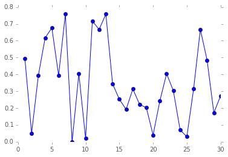

```python
%pylab inline
plot(day[mask], norm_vel[mask], 'bo-')
```

## Linear algebra

Express operations in terms of arrays and matrics to get optimal speed (compiled functions).

### Scalar-array operations

We can use the usual arithmetic operators to multiply, add, subtract, and divide arrays with scalar numbers.

```python
v1 = nb.arange(0, 5)
```

```python
v1 * 2
```

```
array([0, 2, 4, 6, 8])
```

```python
v1 + 2
```

```
array([2, 3, 4, 5, 6])
```

### Element-wise array-array operations

When we add, subtract, multiply and divide arrays with each other, the default behaviour is **element-wise** operations:

```python
v1 * v1
```

```
array([ 0,  1,  4,  9, 16])
```

### Matrix algebra

```python
nb.dot(v1, v1)
```

```
30
```

### Data computations

Often it is useful to store datasets in Numpy arrays. Numpy provides a number of functions to calculate statistics of datasets in arrays.

```python
nb.shape(norm_vel)
norm_vel
```

```
array([ 0.17171717, -2.        , -3.        , ...,  0.39393939,
        0.50505051,  0.22222222])
```

#### mean

```python
nb.mean(norm_vel[:])
```

```
0.32125420875421096
```

#### min and max

```python
norm_vel.min()
```

```
-3.0
```

```python
norm_vel.max()
```

```
1.0
```

## Further reading

- http://numpy.scipy.org
- http://scipy.org/Tentative_NumPy_Tutorial
- http://scipy.org/NumPy_for_Matlab_Users - A Numpy guide for MATLAB users.
- http://wiki.scipy.org/Cookbook

This tutorial was adapted from J.R. Johansson scientific python Numpy lecture https://github.com/jrjohansson/scientific-python-lectures/blob/master/Lecture-2-Numpy.ipynb that is licensed under a a Creative Commons Attribution 3.0 Unported License.